# DATA 606 Project Proposal

Samuel I Kigamba

October 14, 2019

### Data Preparation

```r
# load data
#install.packages("fueleconomy")
library(plyr)
library(dplyr)
library(tidyverse)
library(tidyr)
library(tidyselect)
#data("vehicles")
```

I saved the data as a csv file in my local drive and uploaded the output into my github repository for ease of accessibility, and to ensure that anyone running my file has access to it.

```r
#write.csv(vehicles, file = "vehicles.csv")
#vehicles <- read.csv(file = "vehicles.csv")
#head(vehicles)
```

Reading the data from my github repository.

```r
vehicles <- read_csv("https://raw.githubusercontent.com/igukusamuel/DATA-606-Project-Proposal/master/vehicles.csv")
head(vehicles)
```

```
## # A tibble: 6 x 13
##      X1    id make   model   year class trans drive   cyl displ fuel    hwy
##   <dbl> <dbl> <chr>  <chr>  <dbl> <chr> <chr> <chr> <dbl> <dbl> <chr> <dbl>
## 1     1 27550 AM Ge~ DJ Po~  1984 Spec~ Auto~ 2-Wh~     4   2.5 Regu~    17
## 2     2 28426 AM Ge~ DJ Po~  1984 Spec~ Auto~ 2-Wh~     4   2.5 Regu~    17
## 3     3 27549 AM Ge~ FJ8c ~  1984 Spec~ Auto~ 2-Wh~     6   4.2 Regu~    13
## 4     4 28425 AM Ge~ FJ8c ~  1984 Spec~ Auto~ 2-Wh~     6   4.2 Regu~    13
## 5     5  1032 AM Ge~ Post ~  1985 Spec~ Auto~ Rear~     4   2.5 Regu~    17
## 6     6  1033 AM Ge~ Post ~  1985 Spec~ Auto~ Rear~     6   4.2 Regu~    13
## # ... with 1 more variable: cty <dbl>
```

### Research question

**You should phrase your research question in a way that matches up with the scope of inference your dataset allows for.**

Is the number of cylinders in a vehicle predictive of fuel economy?

### Cases

**What are the cases, and how many are there?**

Each case represents a vehicle cylinders. There are (nrow <- length(vehicles$cyl)) 33,442 observations in the given data set.

```r
nrow <- length(vehicles$cyl)
nrow
```

```
## [1] 33442
```

### Data collection

**Describe the method of data collection.**

Fuel economy data for all cars sold in the US from 1984 to 2015 is collected by the Environmental protection agency. (Source: https://www.fueleconomy.gov/feg/download.shtml). This is as a result of vehicle testing done at the Environmental Protection Agency’s National Vehicle and Fuel Emissions Laboratory in Ann Arbor, Michigan, and by vehicle manufacturers with oversight by EPA.

### Type of study

**What type of study is this (observational/experiment)?**

This is an observational study.

### Data Source

**If you collected the data, state self-collected. If not, provide a citation/link.**

Fuel economy data for all cars sold in the US from 1984 to 2015 is collected by the Environmental protection agency and is available online here (Source: https://www.fueleconomy.gov/feg/download.shtml). We have extracted it using fueleconomy package available under R (install.packages(“fueleconomy”)).

### Dependent Variable

**What is the response variable? Is it quantitative or qualitative?**

The response variable is the highway fuel consumption/economy and is numerical.

### Independent Variable

**You should have two independent variables, one quantitative and one qualitative.**

The independent variable is the number of cylinders (cyl) in the vehicles and is numerical.

### Relevant summary statistics

**Provide summary statistics for each the variables. Also include appropriate visualizations related to your research question (e.g. scatter plot, boxplots, etc). This step requires the use of R, hence a code chunk is provided below. Insert more code chunks as needed.**

```r
summary(vehicles$cyl)
```

```
##    Min. 1st Qu.  Median    Mean 3rd Qu.    Max.    NA's
##   2.000   4.000   6.000   5.772   6.000  16.000      58
```

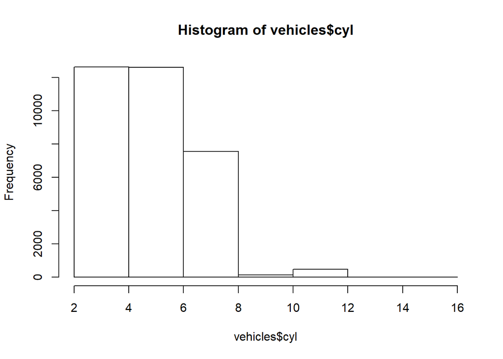

```r
hist(vehicles$cyl, breaks = 5)
```

```r
summary(vehicles$hwy)
```

```
##    Min. 1st Qu.  Median    Mean 3rd Qu.    Max.
##    9.00   19.00   23.00   23.55   27.00  109.00
```

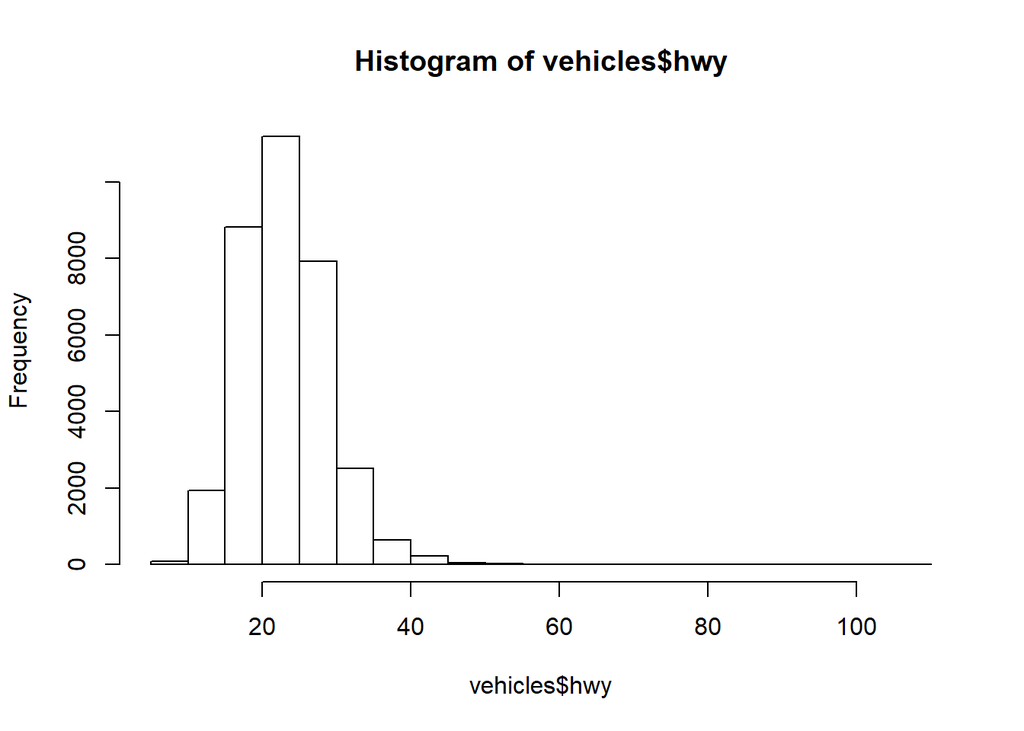

```r
hist(vehicles$hwy, breaks = 30)
```

```r
line(vehicles$hwy)
```

```
##
## Call:
## line(vehicles$hwy)
##
## Coefficients:
## [1]  2.086e+01  1.346e-04
```

```r
summary(vehicles$hwy)
```

```
##    Min. 1st Qu.  Median    Mean 3rd Qu.    Max.
##    9.00   19.00   23.00   23.55   27.00  109.00
```

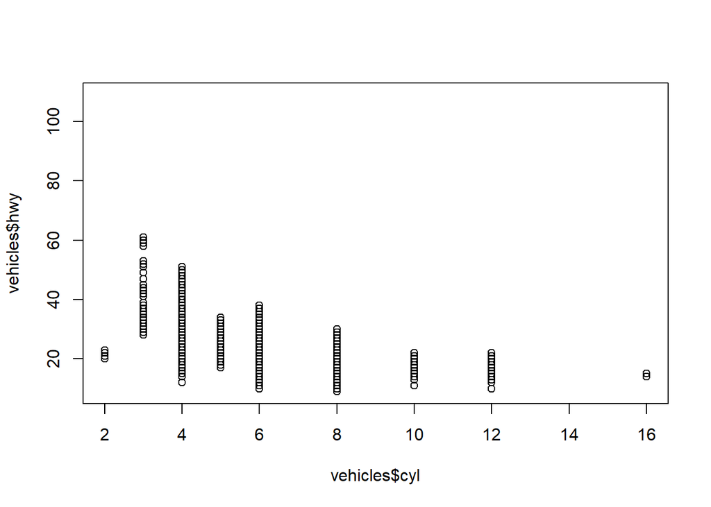

```r
plot(vehicles$cyl, vehicles$hwy)
```

```r
summary(vehicles$hwy)
```

```
##    Min. 1st Qu.  Median    Mean 3rd Qu.    Max.
##    9.00   19.00   23.00   23.55   27.00  109.00
```

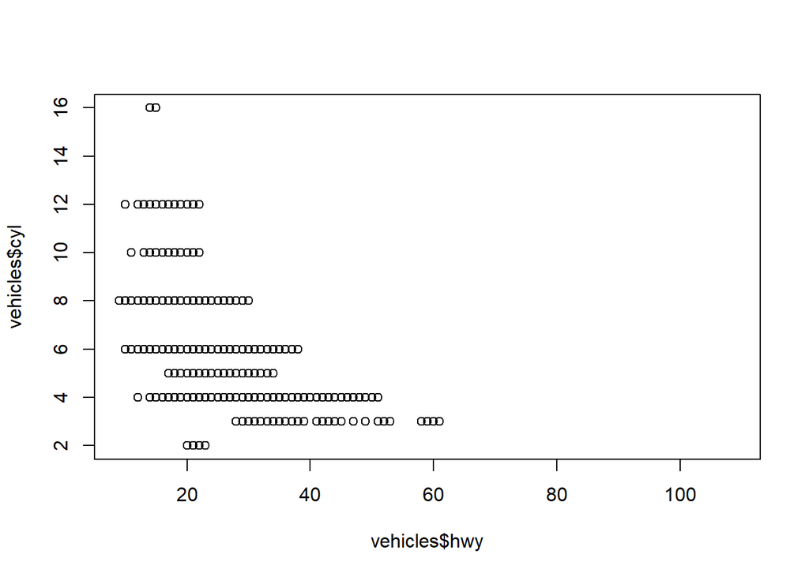

```r
plot(vehicles$hwy, vehicles$cyl)
```